# La Latitud define la temperatura de un lugar?

Harvey Rodriguez Gil

Mayo 7, 2021

# Descripción de la base de datos

**fuente**

El archivo fuente utilizado se encuentra en la carpeta sources, y fue originalmente obtenido desde *Kaggle*: [*Historical Daily Weather Data 2020*](https://www.kaggle.com/vishalvjoseph/weather-dataset-for-covid19-predictions)

**Descripción de la información**

Este conjunto de datos contiene la información diaria del clima para 163 países (algunos con información de estados/provincias) desde el 1º de Enero de 2020 hasta el 20 de Abril de 2020. La lista de los países fue basado en el conjunto de datos de John Hopkins COVID-19.

# Descripción de las variables

A continuación se describiran las variables utilizadas en el ejercicio:

- **Country/Region:** país a los que le corresponden los datos
- **Province/State:** estado del pais al que le corresponde los datos.
- **Time:** fecha en la que fueron tomados los datos
- **Summary:** texto resumen (humano) del estado del clima.
- **Icon:** texto resumen (máquina) del estado del clima. Utilizado para presentar un ícono que represente el estado del clima.
- **Humidity:** humedad relativa
- **Pressure:** Presión del aíre
- **TemperatureMin:** Temperatura mínima registrada para un día
- **TemperatureMax:** Temperatura máxima registrada para un día

# Pasos iniciales

Carga de la información del clima de todos los países y creación de los dataframes para cada uno de los estados a analizar:

```r
url <- '/Users/hrodriguez/Downloads/daily_weather_2020.csv'
all_countries <- read.csv(url)
california <- subset(all_countries, Country.Region == 'US' & Province.State == 'California')
new_york <- subset(all_countries, Country.Region == 'US' & Province.State == 'New York')
```

# Análisis Descriptivo - California

### Pruebas de normalidad: qqPlot e histograma para los datos de Temperatura

```r
par(mfrow=c(1, 2))
require(car)
```

```r
qqPlot(california$temperatureMin, pch = 19,
       main = 'QQplot Temp. California',
       ylab = 'Cuantiles muestrales',
       xlab = 'Cuantiles teóricos')
```

```
## [1] 36 37
```

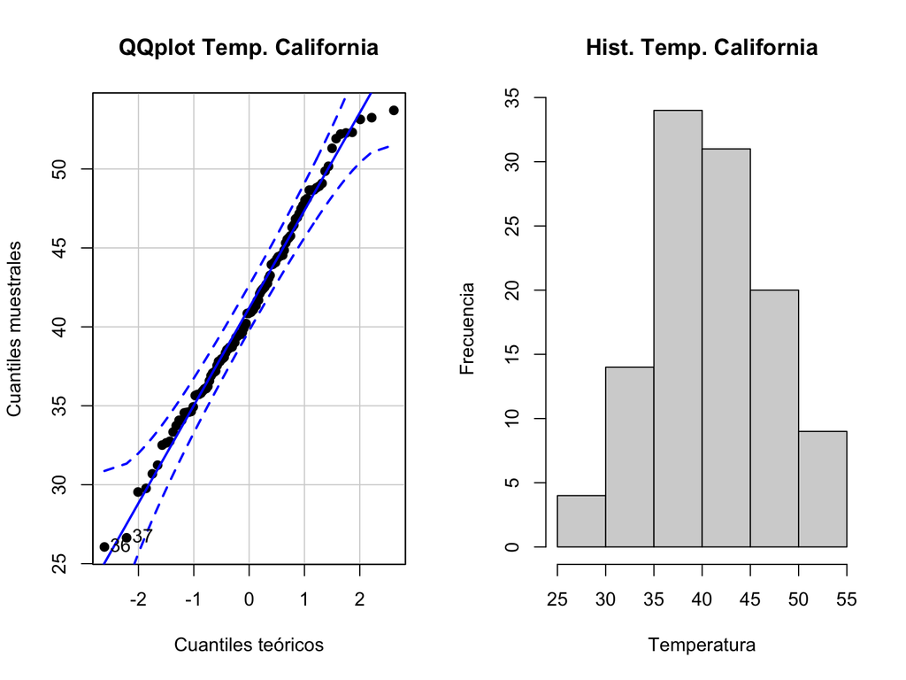

```r
hist(california$temperatureMin, freq = T,
     main='Hist. Temp. California',
     ylab = 'Frecuencia',
     xlab = 'Temperatura')
```